# Regression iiD

Keyon Hedayati

4/21/2022

```r
library(tidyverse)
library(caret)
```

```r
library(coefplot)
library(recipes)
df_all <- readr::read_csv("final_project_train.csv", col_names = TRUE)
```

Load the data and transform y

```r
dfii <- df_all %>%
  mutate(y = log(response)) %>%
  select(region, customer, starts_with('x'), y)
```

**Linear Models**

Preprocessing Settings:

```r
my_ctrl <- trainControl(method = "repeatedcv", number = 10, repeats = 3)
my_ctrl_pca <- trainControl(method = "repeatedcv", number = 10, repeats = 3, preProcOptions = list(pcaComp = 25))
my_metric <- 'RMSE'
```

A linear additive features with all categorical and continuous

```r
set.seed(888)
fit_lm_all_add <- train(y ~ ., data = dfii,
                 method = "lm",
                 preProcess = c("center", "scale"),
                 metric = my_metric,
                 trControl = my_ctrl)

fit_lm_all_add
```

```
## Linear Regression
##
## 677 samples
##  35 predictor
##
## Pre-processing: centered (43), scaled (43)
## Resampling: Cross-Validated (10 fold, repeated 3 times)
## Summary of sample sizes: 609, 609, 609, 609, 609, 610, ...
## Resampling results:
##
##   RMSE       Rsquared   MAE
##   0.3288514  0.6300572  0.2545318
##
## Tuning parameter 'intercept' was held constant at a value of TRUE
```

All pairwise interactions of continuous also with additive categorical features

```r
set.seed(888)
fit_cont_pairs_cat_add <- train(y ~ customer + region + (. -customer -region)^2,
                        data = dfii,
                        method = "lm",
                        preProcess = c("center", "scale", "pca"),
                        metric = my_metric,
                        trControl = my_ctrl_pca)


fit_cont_pairs_cat_add
```

```
## Linear Regression
##
## 677 samples
##  35 predictor
##
## Pre-processing: centered (571), scaled (571), principal component
##  signal extraction (571)
## Resampling: Cross-Validated (10 fold, repeated 3 times)
## Summary of sample sizes: 609, 609, 609, 609, 609, 610, ...
## Resampling results:
##
##   RMSE       Rsquared   MAE
##   0.3779959  0.5149558  0.284139
##
## Tuning parameter 'intercept' was held constant at a value of TRUE
```

First model saved from iiA. Since it was the winner I choose, and it is the same model as above (everything additive), I will run it with PCA

```r
re_lm_all_add <- readr::read_rds('lm_all_additive.rds')

set.seed(888)
fit_lm_all_add <- train(y ~ .,
                        data = dfii,
                        method = "lm",
                        preProcess = c("center", "scale", "pca"),
                        metric = my_metric,
                        trControl = my_ctrl_pca)


fit_lm_all_add
```

```
## Linear Regression
##
## 677 samples
##  35 predictor
##
## Pre-processing: centered (43), scaled (43), principal component
##  signal extraction (43)
## Resampling: Cross-Validated (10 fold, repeated 3 times)
## Summary of sample sizes: 609, 609, 609, 609, 609, 610, ...
## Resampling results:
##
##   RMSE       Rsquared   MAE
##   0.3338793  0.6188863  0.2594404
##
## Tuning parameter 'intercept' was held constant at a value of TRUE
```

Second model chosen from iiA was one I designed. It included customer as additive, and region interaction with select splines that I chose from exploration. Any of the inputs that have a spline, I removed them as additive.

```r
re_lm_cont_cust_add_region_X_spline <- readr::read_rds('lm_cont_cust_add_region_X_splines.rds')

set.seed(888)
fit_lm_cont_cust_add_region_X_spline <- train(y ~
                    (. -xa_02 -xb_02 -xb_05 -xn_02 -xw_02 -xw_03 -xs_02 -xs_03 -xs_05 -xs_06) + region *
                     splines::ns(xa_02, df = 4) +
                     splines::ns(xb_02, df = 4) +
                     splines::ns(xb_05, df = 4) +
                     splines::ns(xn_02, df = 4) +
                     splines::ns(xw_02, df = 4) +
                     splines::ns(xw_03, df = 4) +
                     splines::ns(xs_02, df = 4) +
                     splines::ns(xs_03, df = 4) +
                     splines::ns(xs_05, df = 4) +
                     splines::ns(xs_06, df = 4) ,
                     data = dfii,
                        method = "lm",
                        preProcess = c("center", "scale"),
                        metric = my_metric,
                        trControl = my_ctrl)


fit_lm_cont_cust_add_region_X_spline
```

```
## Linear Regression
##
## 677 samples
##  35 predictor
##
## Pre-processing: centered (81), scaled (81)
## Resampling: Cross-Validated (10 fold, repeated 3 times)
## Summary of sample sizes: 609, 609, 609, 609, 609, 610, ...
## Resampling results:
##
##   RMSE      Rsquared   MAE
##   0.325205  0.6417941  0.2515657
##
## Tuning parameter 'intercept' was held constant at a value of TRUE
```

*Regularization with Elastic Net*

All pairwise with categorical additive using Elastic net.

```r
set.seed(888)
glmnet_cont_pairs_cat_add <- train(y ~ customer + region + (. -customer -region)^2,
                        data = dfii,
                        method = "glmnet",
                        preProcess = c("center", "scale"),
                        metric = my_metric,
                        trControl = my_ctrl)

glmnet_cont_pairs_cat_add
```

```
## glmnet
##
## 677 samples
##  35 predictor
##
## Pre-processing: centered (571), scaled (571)
## Resampling: Cross-Validated (10 fold, repeated 3 times)
## Summary of sample sizes: 609, 609, 609, 609, 609, 610, ...
## Resampling results across tuning parameters:
##
##   alpha  lambda        RMSE       Rsquared   MAE
##   0.10   0.0006280634  0.3648707  0.5976667  0.2826306
##   0.10   0.0062806336  0.3072083  0.6830279  0.2396338
##   0.10   0.0628063363  0.3146099  0.6608652  0.2424051
##   0.55   0.0006280634  0.3321255  0.6452119  0.2589189
##   0.55   0.0062806336  0.3078296  0.6763705  0.2381080
##   0.55   0.0628063363  0.3418443  0.6087278  0.2646209
##   1.00   0.0006280634  0.3162973  0.6694217  0.2475608
##   1.00   0.0062806336  0.3142484  0.6617259  0.2421062
##   1.00   0.0628063363  0.3587484  0.5862870  0.2783153
##
## RMSE was used to select the optimal model using the smallest value.
## The final values used for the model were alpha = 0.1 and lambda = 0.006280634.
```

The more complicated model from iiA

```r
set.seed(888)
glmnet_lm_cont_cust_add_region_X_spline <- train(y ~
                    (. -xa_02 -xb_02 -xb_05 -xn_02 -xw_02 -xw_03 -xs_02 -xs_03 -xs_05 -xs_06) + region *
                     splines::ns(xa_02, df = 4) +
                     splines::ns(xb_02, df = 4) +
                     splines::ns(xb_05, df = 4) +
                     splines::ns(xn_02, df = 4) +
                     splines::ns(xw_02, df = 4) +
                     splines::ns(xw_03, df = 4) +
                     splines::ns(xs_02, df = 4) +
                     splines::ns(xs_03, df = 4) +
                     splines::ns(xs_05, df = 4) +
                     splines::ns(xs_06, df = 4) ,
                     data = dfii,
                        method = "glmnet",
                        preProcess = c("center", "scale"),
                        metric = my_metric,
                        trControl = my_ctrl)


glmnet_lm_cont_cust_add_region_X_spline
```

```
## glmnet
##
## 677 samples
##  35 predictor
##
## Pre-processing: centered (81), scaled (81)
## Resampling: Cross-Validated (10 fold, repeated 3 times)
## Summary of sample sizes: 609, 609, 609, 609, 609, 610, ...
## Resampling results across tuning parameters:
##
##   alpha  lambda        RMSE       Rsquared   MAE
##   0.10   0.0005747904  0.3231269  0.6450711  0.2500800
##   0.10   0.0057479037  0.3202456  0.6483442  0.2471983
##   0.10   0.0574790374  0.3200480  0.6472641  0.2478863
##   0.55   0.0005747904  0.3219796  0.6467491  0.2492158
##   0.55   0.0057479037  0.3188945  0.6489546  0.2467264
##   0.55   0.0574790374  0.3404710  0.6146179  0.2637089
##   1.00   0.0005747904  0.3213377  0.6474048  0.2485869
##   1.00   0.0057479037  0.3201897  0.6458199  0.2477781
##   1.00   0.0574790374  0.3575266  0.5913155  0.2770685
##
## RMSE was used to select the optimal model using the smallest value.
## The final values used for the model were alpha = 0.55 and lambda = 0.005747904.
```

Custom Tuned Above:

```r
lambda_grid <- exp(seq(log(min(glmnet_lm_cont_cust_add_region_X_spline$results$lambda)),
                          log(max(glmnet_lm_cont_cust_add_region_X_spline$results$lambda)),
                          length.out = 25))

enet_grid <- expand.grid(alpha = seq(0.1, 0.9, length.out = 9),
                         lambda = lambda_grid)
```

```r
set.seed(888)
glmnet_tuned_lm_cont_cust_add_region_X_spline <- train(y ~
                    (. -xa_02 -xb_02 -xb_05 -xn_02 -xw_02 -xw_03 -xs_02 -xs_03 -xs_05 -xs_06) + region *
                     splines::ns(xa_02, df = 4) +
                     splines::ns(xb_02, df = 4) +
                     splines::ns(xb_05, df = 4) +
                     splines::ns(xn_02, df = 4) +
                     splines::ns(xw_02, df = 4) +
                     splines::ns(xw_03, df = 4) +
                     splines::ns(xs_02, df = 4) +
                     splines::ns(xs_03, df = 4) +
                     splines::ns(xs_05, df = 4) +
                     splines::ns(xs_06, df = 4) ,
                     data = dfii,
                        method = "glmnet",
                        tuneGrid = enet_grid,
                        preProcess = c("center", "scale"),
                        metric = my_metric,
                        trControl = my_ctrl)


glmnet_tuned_lm_cont_cust_add_region_X_spline
```

```
## glmnet
##
## 677 samples
##  35 predictor
##
## Pre-processing: centered (81), scaled (81)
## Resampling: Cross-Validated (10 fold, repeated 3 times)
## Summary of sample sizes: 609, 609, 609, 609, 609, 610, ...
## Resampling results across tuning parameters:
##
##   alpha  lambda        RMSE       Rsquared   MAE
##   0.1    0.0005747904  0.3231269  0.6450711  0.2500800
##   0.1    0.0006963744  0.3229274  0.6453725  0.2499253
##   0.1    0.0008436769  0.3226943  0.6457238  0.2497448
##   0.1    0.0010221379  0.3224486  0.6460758  0.2495463
##   0.1    0.0012383483  0.3221906  0.6464555  0.2493449
##   0.1    0.0015002932  0.3219248  0.6468043  0.2491204
##   0.1    0.0018176468  0.3216630  0.6471201  0.2488696
##   0.1    0.0022021293  0.3214127  0.6474133  0.2486136
##   0.1    0.0026679406  0.3211816  0.6476333  0.2483594
##   0.1    0.0032322838  0.3209203  0.6478785  0.2480784
##   0.1    0.0039160012  0.3206509  0.6481369  0.2477501
##   0.1    0.0047443438  0.3204215  0.6483102  0.2474334
##   0.1    0.0057479037  0.3202456  0.6483442  0.2471983
##   0.1    0.0069637444  0.3201323  0.6482262  0.2471032
##   0.1    0.0084367689  0.3200059  0.6481224  0.2470382
##   0.1    0.0102213789  0.3198016  0.6481706  0.2469275
##   0.1    0.0123834832  0.3195511  0.6483301  0.2468214
##   0.1    0.0150029324  0.3193045  0.6485020  0.2466980
##   0.1    0.0181764676  0.3190296  0.6487852  0.2465426
##   0.1    0.0220212932  0.3188207  0.6489888  0.2464180
##   0.1    0.0266794058  0.3187075  0.6491025  0.2464112
##   0.1    0.0323228381  0.3187733  0.6489326  0.2465675
##   0.1    0.0391600123  0.3190472  0.6484625  0.2468399
##   0.1    0.0474434380  0.3194605  0.6478960  0.2472803
##   0.1    0.0574790374  0.3200480  0.6472641  0.2478863
##   0.2    0.0005747904  0.3228323  0.6455549  0.2498660
##   0.2    0.0006963744  0.3225967  0.6458928  0.2496845
##   0.2    0.0008436769  0.3223412  0.6462540  0.2494849
##   0.2    0.0010221379  0.3220528  0.6466663  0.2492537
```

[output cut: 184 more lines]

```
##   0.9    0.0069637444  0.3204065  0.6454513  0.2480742
##   0.9    0.0084367689  0.3207118  0.6450809  0.2486077
##   0.9    0.0102213789  0.3210653  0.6448161  0.2491968
##   0.9    0.0123834832  0.3217320  0.6439779  0.2499179
##   0.9    0.0150029324  0.3231841  0.6416340  0.2509555
##   0.9    0.0181764676  0.3255615  0.6373958  0.2527369
##   0.9    0.0220212932  0.3289831  0.6309931  0.2553680
##   0.9    0.0266794058  0.3326694  0.6246689  0.2580411
##   0.9    0.0323228381  0.3367131  0.6184180  0.2608379
##   0.9    0.0391600123  0.3419396  0.6102224  0.2647018
##   0.9    0.0474434380  0.3481055  0.6009821  0.2694636
##   0.9    0.0574790374  0.3542640  0.5945818  0.2744725
##
## RMSE was used to select the optimal model using the smallest value.
## The final values used for the model were alpha = 0.1 and lambda = 0.02667941.
```

*Neural Network*

```r
nnet_grid <- expand.grid(size = c(10, 20, 30, 40),
                         decay = exp(seq(-6, 1, length.out = 11)))
```

Setting eval to false, because takes long with this tunning grid. Instead I’ve saved the model, and will reload it when needed.

```r
set.seed(888)
fit_nnet_tune <- train(y ~ .,
                       data = dfii,
                       method = "nnet",
                       metric = my_metric,
                       tuneGrid = nnet_grid,
                       preProcess = c("center", "scale"),
                       trControl = my_ctrl,
                       maxit = 1000,
                       MaxNWts = 2500,
                       trace=FALSE)



fit_nnet_tune
```

```r
fit_nnet_tune %>% readr::write_rds('nnet_tuned_model.rds')
```

```r
re_nnet_tuned <- readr::read_rds('nnet_tuned_model.rds')
re_nnet_tuned
```

```
## Neural Network
##
## 677 samples
##  35 predictor
##
## Pre-processing: centered (43), scaled (43)
## Resampling: Cross-Validated (10 fold, repeated 3 times)
## Summary of sample sizes: 609, 609, 609, 609, 609, 610, ...
## Resampling results across tuning parameters:
##
##   size  decay        RMSE       Rsquared   MAE
##   10    0.002478752  0.4388305  0.3826369  0.3415633
##   10    0.004991594  0.4309665  0.3992494  0.3330198
##   10    0.010051836  0.4177740  0.4364374  0.3222169
##   10    0.020241911  0.4128737  0.4557299  0.3171680
```

[output cut: 43 more lines]

*Random Forest*

```r
rf_grid <- expand.grid(mtry = c(2, 5, 7, 10, 12, 15, 18, 20, 22, 24, 26, 30, 40, 45, 50, 60))
```

Even with extra tuning, mtry of 22 still works the best. Setting eval to False to save time, and saving the model to be imported when needed. The tuning grid takes some time to run.

```r
set.seed(888)
fit_rf_tuned <- train(y ~ .,
                      data = dfii,
                      method = 'rf',
                      metric = my_metric,
                      tuneGrid = rf_grid,
                      trControl = my_ctrl,
                      importance = TRUE)


fit_rf_tuned
```

```r
re_fit_rf_tuned <- readr::read_rds('fit_rf_tuned_model.rds')
re_fit_rf_tuned
```

```
## Random Forest
##
## 677 samples
##  35 predictor
##
## No pre-processing
## Resampling: Cross-Validated (10 fold, repeated 3 times)
## Summary of sample sizes: 609, 609, 609, 609, 609, 610, ...
## Resampling results across tuning parameters:
##
##   mtry  RMSE       Rsquared   MAE
##    2    0.3509548  0.6333382  0.2723911
##    5    0.3279853  0.6583410  0.2524557
##    7    0.3219383  0.6644244  0.2470666
##   10    0.3176501  0.6672593  0.2434101
##   12    0.3157691  0.6683787  0.2422731
##   15    0.3146502  0.6671146  0.2409374
##   18    0.3137922  0.6673644  0.2405521
##   20    0.3137122  0.6658150  0.2402693
##   22    0.3130683  0.6666253  0.2397898
##   24    0.3132289  0.6648404  0.2399462
##   26    0.3134145  0.6636563  0.2401672
##   30    0.3133341  0.6625838  0.2402986
##   40    0.3157870  0.6547435  0.2425493
##   45    0.3167779  0.6520456  0.2435649
##   50    0.3162139  0.6534801  0.2432323
##   60    0.3167948  0.6522439  0.2435259
##
## RMSE was used to select the optimal model using the smallest value.
## The final value used for the model was mtry = 22.
```

```r
fit_rf_tuned %>% readr::write_rds('fit_rf_tuned_model.rds')
```

```r
set.seed(888)
fit_rf <- train(y ~ .,
                      data = dfii,
                      method = 'rf',
                      metric = my_metric,
                      #tuneGrid = rf_grid,
                      trControl = my_ctrl,
                      importance = TRUE)


fit_rf
```

```
## Random Forest
##
## 677 samples
##  35 predictor
##
## No pre-processing
## Resampling: Cross-Validated (10 fold, repeated 3 times)
## Summary of sample sizes: 609, 609, 609, 609, 609, 610, ...
## Resampling results across tuning parameters:
##
##   mtry  RMSE       Rsquared   MAE
##    2    0.3516167  0.6324766  0.2733133
##   22    0.3140381  0.6637935  0.2406608
##   43    0.3165380  0.6530222  0.2433265
##
## RMSE was used to select the optimal model using the smallest value.
## The final value used for the model was mtry = 22.
```

*Gradient Boosted Tree*

```r
set.seed(888)
fit_xgb <- train(y ~ .,
                      data = dfii,
                      method = 'xgbTree',
                      metric = my_metric,
                      trControl = my_ctrl,
                      importance = TRUE)

print("please don't show all the warning messages")
```

```r
re_fit_xgb <- readr::read_rds('fit_xgb_model.rds')
re_fit_xgb
```

```
## eXtreme Gradient Boosting
##
## 677 samples
##  35 predictor
##
## No pre-processing
## Resampling: Cross-Validated (10 fold, repeated 3 times)
## Summary of sample sizes: 609, 609, 609, 609, 609, 610, ...
## Resampling results across tuning parameters:
##
##   eta  max_depth  colsample_bytree  subsample  nrounds  RMSE       Rsquared
##   0.3  1          0.6               0.50        50      0.3384198  0.6022304
##   0.3  1          0.6               0.50       100      0.3372031  0.6075500
##   0.3  1          0.6               0.50       150      0.3385132  0.6072671
##   0.3  1          0.6               0.75        50      0.3366785  0.6063780
##   0.3  1          0.6               0.75       100      0.3330003  0.6161138
##   0.3  1          0.6               0.75       150      0.3341620  0.6153346
##   0.3  1          0.6               1.00        50      0.3372045  0.6069887
##   0.3  1          0.6               1.00       100      0.3330126  0.6144394
##   0.3  1          0.6               1.00       150      0.3320430  0.6166393
##   0.3  1          0.8               0.50        50      0.3359084  0.6064783
##   0.3  1          0.8               0.50       100      0.3374397  0.6067993
##   0.3  1          0.8               0.50       150      0.3383060  0.6081235
##   0.3  1          0.8               0.75        50      0.3351019  0.6097826
##   0.3  1          0.8               0.75       100      0.3306338  0.6220249
##   0.3  1          0.8               0.75       150      0.3333735  0.6173418
##   0.3  1          0.8               1.00        50      0.3378591  0.6057773
##   0.3  1          0.8               1.00       100      0.3307784  0.6197642
##   0.3  1          0.8               1.00       150      0.3300315  0.6217974
##   0.3  2          0.6               0.50        50      0.3237158  0.6377779
##   0.3  2          0.6               0.50       100      0.3271997  0.6353292
##   0.3  2          0.6               0.50       150      0.3292525  0.6333705
##   0.3  2          0.6               0.75        50      0.3168368  0.6501219
##   0.3  2          0.6               0.75       100      0.3149714  0.6564543
##   0.3  2          0.6               0.75       150      0.3162166  0.6551577
##   0.3  2          0.6               1.00        50      0.3125720  0.6611927
##   0.3  2          0.6               1.00       100      0.3100824  0.6673393
##   0.3  2          0.6               1.00       150      0.3130447  0.6615705
##   0.3  2          0.8               0.50        50      0.3195004  0.6470443
##   0.3  2          0.8               0.50       100      0.3211202  0.6458317
```

[output cut: 181 more lines]

```
##   0.2732305
##   0.2574725
##   0.2617465
##   0.2622944
##   0.2495014
##   0.2539337
##   0.2547044
##
## Tuning parameter 'gamma' was held constant at a value of 0
## Tuning
##  parameter 'min_child_weight' was held constant at a value of 1
## RMSE was used to select the optimal model using the smallest value.
## The final values used for the model were nrounds = 50, max_depth = 3, eta
##  = 0.3, gamma = 0, colsample_bytree = 0.8, min_child_weight = 1 and subsample
##  = 0.75.
```

```r
fit_xgb %>% readr::write_rds('fit_xgb_model.rds')
```

*Choice #1 Bagged Mars*

```r
BAG_grid <- expand.grid(nprune = c(6, 8, 12, 15, 21),
                         degree = seq.int(1, 5))
```

```r
set.seed(888)
fit_bag <- train(y ~ .,
                      data = dfii,
                      method = 'bagEarth',
                      metric = my_metric,
                      trControl = my_ctrl
)
fit_bag
```

```
## Bagged MARS
##
## 677 samples
##  35 predictor
##
## No pre-processing
## Resampling: Cross-Validated (10 fold, repeated 3 times)
## Summary of sample sizes: 609, 609, 609, 609, 609, 610, ...
## Resampling results across tuning parameters:
##
##   nprune  RMSE       Rsquared   MAE
##    2      0.4431793  0.3233555  0.3436324
##   12      0.3174846  0.6495783  0.2445624
##   23      0.3178973  0.6506184  0.2446387
##
## Tuning parameter 'degree' was held constant at a value of 1
## RMSE was used to select the optimal model using the smallest value.
## The final values used for the model were nprune = 12 and degree = 1.
```

```r
set.seed(888)
fit_bag_tune <- train(y ~ .,
                      data = dfii,
                      method = 'bagEarth',
                      metric = my_metric,
                      trControl = my_ctrl,
                     tuneGrid= BAG_grid
)
fit_bag_tune
```

```r
re_fit_bag_tune <- readr::read_rds('bagged_MARS_tuned.rds')
re_fit_bag_tune
```

```
## Bagged MARS
##
## 677 samples
##  35 predictor
##
## No pre-processing
## Resampling: Cross-Validated (10 fold, repeated 3 times)
## Summary of sample sizes: 609, 609, 609, 609, 609, 610, ...
## Resampling results across tuning parameters:
##
##   degree  nprune  RMSE       Rsquared   MAE
##   1        6      0.3351082  0.6113006  0.2560942
##   1        8      0.3249027  0.6333467  0.2486974
##   1       12      0.3177038  0.6485792  0.2447859
##   1       15      0.3148162  0.6554476  0.2431494
##   1       21      0.3165699  0.6523022  0.2441687
##   2        6      0.3135295  0.6615779  0.2387139
##   2        8      0.2990658  0.6908807  0.2315898
##   2       12      0.2880687  0.7130637  0.2245521
##   2       15      0.2845089  0.7182312  0.2212347
##   2       21      0.2843726  0.7203285  0.2209196
##   3        6      0.3121409  0.6663512  0.2405571
##   3        8      0.2968551  0.6959095  0.2292843
##   3       12      0.2844624  0.7198771  0.2222263
##   3       15      0.2795450  0.7286445  0.2193965
##   3       21      0.2783061  0.7316451  0.2185493
##   4        6      0.3147233  0.6617346  0.2425715
##   4        8      0.2963536  0.6985015  0.2294247
##   4       12      0.2830238  0.7226779  0.2212427
##   4       15      0.2790922  0.7309299  0.2191249
##   4       21      0.2731195  0.7417532  0.2147932
##   5        6      0.3123193  0.6678935  0.2404094
##   5        8      0.2975024  0.6960587  0.2304496
##   5       12      0.2862516  0.7168172  0.2232388
##   5       15      0.2784534  0.7318991  0.2186027
##   5       21      0.3807129  0.7202480  0.2300867
##
## RMSE was used to select the optimal model using the smallest value.
## The final values used for the model were nprune = 21 and degree = 4.
```

It took forever to run, so I don’t want to ever run it again. So I’m saving the model to be imported when needed. The non-tuned MARS bagging is above.

```r
fit_bag_tune %>% readr::write_rds('bagged_MARS_tuned_2.rds')
```

*Choice #2 SVM Radial*

```r
svm_radial <- expand.grid(sigma = seq(.001,.015,length.out=10),
                         C = seq(5, 8, by=.5))
```

Because this model takes awhile to run with this grid, I’ve set chunk to False and exported the model

```r
set.seed(888)
fit_svm_radial <- train(y ~ .,
                  data = dfii,
                  method = 'svmRadial',
                  metric = my_metric,
                  preProcess = c("center", "scale"),
                  tuneGrid = svm_radial,
                  trControl = my_ctrl

                  )

fit_svm_radial
```

```r
fit_svm_radial %>% readr::write_rds('svm_radial_tuned_model.rds')
```

Because some of the models take a long time to run with their respective tuning grids, I’ve saved them to be reloaded here. That way we can still visualize their performance without needing to rerun them all.

```r
re_fit_svm_radial <- readr::read_rds('svm_radial_tuned_model.rds')
re_fit_svm_radial
```

```
## Support Vector Machines with Radial Basis Function Kernel
##
## 677 samples
##  35 predictor
##
## Pre-processing: centered (43), scaled (43)
## Resampling: Cross-Validated (10 fold, repeated 3 times)
## Summary of sample sizes: 609, 609, 609, 609, 609, 610, ...
## Resampling results across tuning parameters:
##
##   sigma        C    RMSE       Rsquared   MAE
##   0.001000000  5.0  0.3077607  0.6750428  0.2383177
##   0.001000000  5.5  0.3068145  0.6768201  0.2376323
##   0.001000000  6.0  0.3060200  0.6783507  0.2370224
##   0.001000000  6.5  0.3053198  0.6796048  0.2364847
##   0.001000000  7.0  0.3046666  0.6808277  0.2359826
##   0.001000000  7.5  0.3039712  0.6821773  0.2354529
##   0.001000000  8.0  0.3034226  0.6832120  0.2350073
##   0.002555556  5.0  0.2846964  0.7204501  0.2225744
##   0.002555556  5.5  0.2834531  0.7227666  0.2216782
##   0.002555556  6.0  0.2821873  0.7251398  0.2207450
##   0.002555556  6.5  0.2809574  0.7273454  0.2198450
##   0.002555556  7.0  0.2797704  0.7295354  0.2190323
##   0.002555556  7.5  0.2786515  0.7316068  0.2182622
##   0.002555556  8.0  0.2776142  0.7335283  0.2174761
##   0.004111111  5.0  0.2721777  0.7435451  0.2137529
##   0.004111111  5.5  0.2709968  0.7456253  0.2129569
##   0.004111111  6.0  0.2699960  0.7473992  0.2122407
##   0.004111111  6.5  0.2691411  0.7488731  0.2115865
##   0.004111111  7.0  0.2682862  0.7503282  0.2108949
##   0.004111111  7.5  0.2675164  0.7516487  0.2102101
##   0.004111111  8.0  0.2668313  0.7527999  0.2096303
##   0.005666667  5.0  0.2660933  0.7542175  0.2091117
##   0.005666667  5.5  0.2653141  0.7554671  0.2085120
##   0.005666667  6.0  0.2646207  0.7565187  0.2080427
##   0.005666667  6.5  0.2641215  0.7571971  0.2077468
##   0.005666667  7.0  0.2637535  0.7576551  0.2075314
##   0.005666667  7.5  0.2635088  0.7579144  0.2073959
##   0.005666667  8.0  0.2633178  0.7580934  0.2073005
##   0.007222222  5.0  0.2644235  0.7563540  0.2080652
```

[output cut: 29 more lines]

```
##   0.013444444  6.0  0.2764169  0.7330055  0.2178138
##   0.013444444  6.5  0.2774670  0.7309452  0.2186763
##   0.013444444  7.0  0.2783830  0.7291663  0.2194021
##   0.013444444  7.5  0.2792041  0.7275969  0.2201164
##   0.013444444  8.0  0.2799089  0.7262740  0.2207562
##   0.015000000  5.0  0.2782174  0.7297227  0.2187864
##   0.015000000  5.5  0.2792562  0.7276141  0.2196991
##   0.015000000  6.0  0.2801189  0.7259036  0.2204477
##   0.015000000  6.5  0.2808891  0.7244038  0.2211339
##   0.015000000  7.0  0.2815737  0.7231279  0.2217187
##   0.015000000  7.5  0.2823068  0.7217646  0.2223766
##   0.015000000  8.0  0.2830881  0.7203002  0.2230507
##
## RMSE was used to select the optimal model using the smallest value.
## The final values used for the model were sigma = 0.005666667 and C = 8.
```

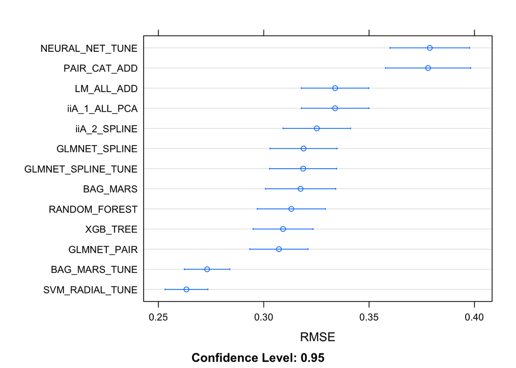

```r
all_cv_summary <- resamples(list(LM_ALL_ADD = fit_lm_all_add,
        PAIR_CAT_ADD = fit_cont_pairs_cat_add,
        iiA_1_ALL_PCA = fit_lm_all_add,
        iiA_2_SPLINE = fit_lm_cont_cust_add_region_X_spline,
        GLMNET_PAIR = glmnet_cont_pairs_cat_add,
        GLMNET_SPLINE = glmnet_lm_cont_cust_add_region_X_spline,
        GLMNET_SPLINE_TUNE = glmnet_tuned_lm_cont_cust_add_region_X_spline,
        NEURAL_NET_TUNE = re_nnet_tuned,
        RANDOM_FOREST = re_fit_rf_tuned,
        XGB_TREE = re_fit_xgb,
        BAG_MARS = fit_bag,
        BAG_MARS_TUNE = re_fit_bag_tune,
        SVM_RADIAL_TUNE = re_fit_svm_radial))


dotplot(all_cv_summary, metric = 'RMSE')
```